# Autumn7 秋第7周上机内容

ChenXG 陈栩淦 3160104014

12/17/2018

```r
Sys.setlocale("LC_ALL", locale = "en_US.UTF-8")
```

```
## [1] "en_US.UTF-8/en_US.UTF-8/en_US.UTF-8/C/en_US.UTF-8/en_US.UTF-8"
```

```r
setwd("~/Project/RegressionAnalysis")
```

## 秋第7周上机内容

为了研究水的耗氧量与周围环境的关系，在实验室条件下，对连续放置220天的水进行不断的测试，一共做了20次观测。选取如下变量进行观察：水的日耗氧量取对数（$y$），生物耗氧量（$x_1$），总的耗氧量（$x_2$），固定物质含量（$x_3$），挥发性固定物质含量（$x_4$），化学物质耗氧量（$x_5$）。其中$x_1$到$x_5$的单位都是$mg/L$，$y$的单位是$mg/min$。数据如下表所示。试给出回归分析，并进行回归诊断，包括模型的诊断和数据的诊断。

```r
# loading data
x1 <- c(1125, 920, 835, 1000, 1150, 990, 840, 650, 640, 583,
        570, 570, 510, 555, 460, 275, 510, 165, 244, 79)
x2 <- c(232, 268, 271, 237, 192, 202, 184, 200, 180, 165,
        151, 171, 243, 147, 286, 198, 196, 210, 327, 334)
x3 <- c(7160, 8804, 8108, 6370, 6441, 5154, 5896, 5336, 5041, 5012,
        4825, 4391, 4320, 3790, 3969, 3558, 4361, 3301, 2964, 2777)
x4 <- c(85.9, 86.5, 85.2, 83.8, 82.1, 79.2, 81.2, 80.6, 78.4, 79.3,
        78.7, 78.0, 72.3, 74.9, 74.4, 72.5, 57.7, 71.8, 72.5, 71.9)
x5 <- c(8905, 7388, 5348, 8056, 6960, 5690, 6932, 5400, 3177, 4461,
        3901, 5002, 4665, 4642, 4840, 4479, 4200, 3410, 3360, 2599)
y <- c(1.5563, 0.8976, 0.7482, 0.716, 0.313, 0.3617, 0.1139, 0.1139, -0.2218, -0.1549,
       0.0000, 0.0000, -0.0969, -0.2218, -0.3979, -0.1540, -0.2218, -0.3919, -0.5229, -0.0458)

data <- data.frame(y, x1, x2, x3, x4, x5)
```

## 回归分析

```r
# 回归分析
lm.sol <- lm(y~., data = data)
summary(lm.sol)
```

```
##
## Call:
## lm(formula = y ~ ., data = data)
##
## Residuals:
##      Min       1Q   Median       3Q      Max
## -0.39469 -0.11855  0.00209  0.08327  0.56281
##
## Coefficients:
##               Estimate Std. Error t value Pr(>|t|)
## (Intercept) -2.157e+00  9.130e-01  -2.363   0.0332 *
## x1          -1.384e-05  5.182e-04  -0.027   0.9791
## x2           1.322e-03  1.261e-03   1.048   0.3123
## x3           1.286e-04  7.720e-05   1.666   0.1179
## x4           7.867e-03  1.401e-02   0.562   0.5833
## x5           1.418e-04  7.375e-05   1.923   0.0751 .
## ---
## Signif. codes:  0 '***' 0.001 '**' 0.01 '*' 0.05 '.' 0.1 ' ' 1
##
## Residual standard error: 0.2618 on 14 degrees of freedom
## Multiple R-squared:  0.8104, Adjusted R-squared:  0.7427
## F-statistic: 11.97 on 5 and 14 DF,  p-value: 0.0001194
```

```r
lm.sol$coefficients
```

```
##   (Intercept)            x1            x2            x3            x4
## -2.157027e+00 -1.384069e-05  1.322039e-03  1.285999e-04  7.866999e-03
##            x5
##  1.418110e-04
```

我们可以得到回归方程：
$$\begin{align}
y = & -1.384069\times10^{-5}\times x_1 + 1.322039 \times10^{-3}\times x_2 + 1.285999 \times10^{-4} \times x_3 \\
& + 7.866999\times10^{-3}\times x_4 + 1.418110 \times10^{-4}\times x_5 -2.157027.
\end{align}$$

## 回归诊断

```r
y.fit <- predict(lm.sol)
e.hat <- residuals(lm.sol)
e.std <- rstandard(lm.sol)
```

### 模型的诊断

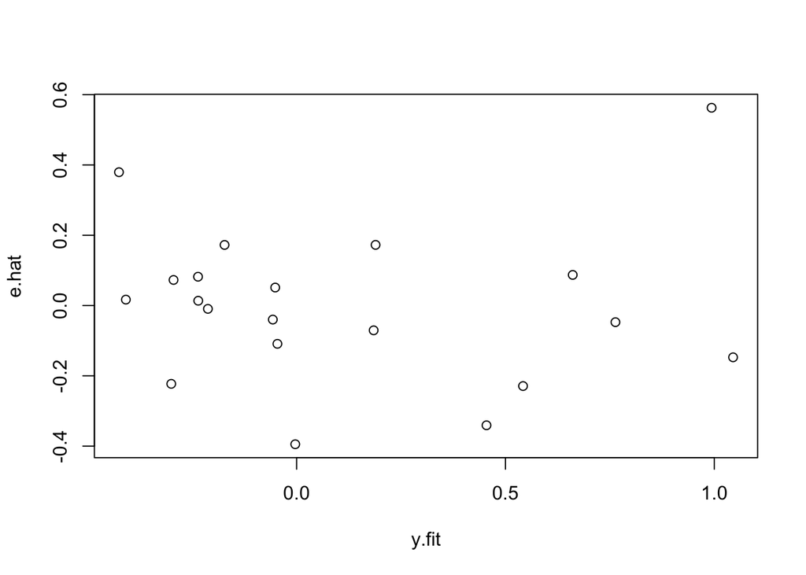

```r
plot(e.hat~y.fit)
```

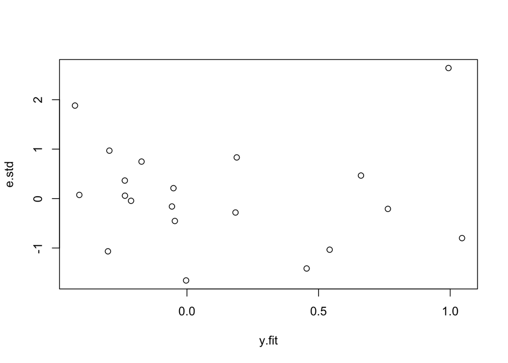

```r
plot(e.std~y.fit)
```

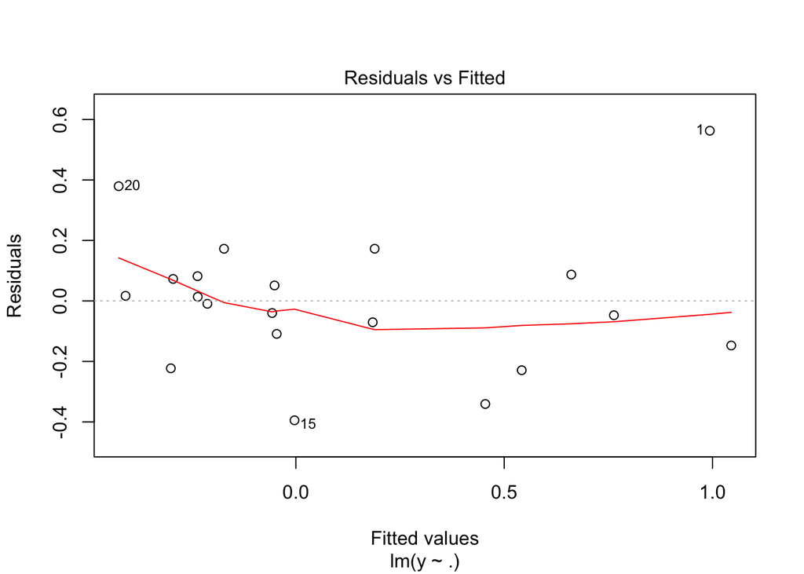

```r
plot(lm.sol, which = 1)
```

通过残差图，我们可以看到这个残差图不呈现任何明显的规则性。

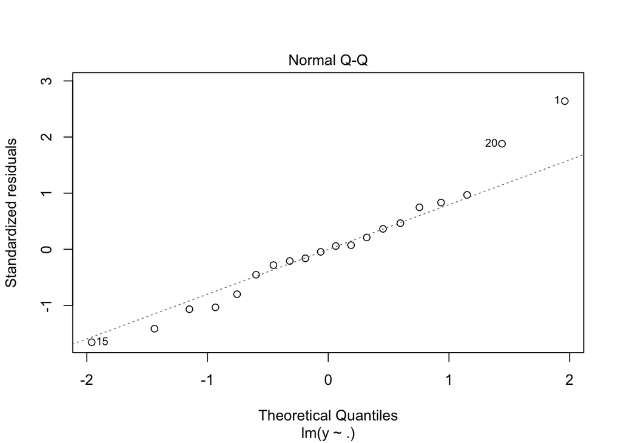

```r
plot(lm.sol, which = 2)
```

通过残差图和QQ图，我们接受线性假设、方差齐性假设、不相关性假设和正态性假设。

### 数据的诊断

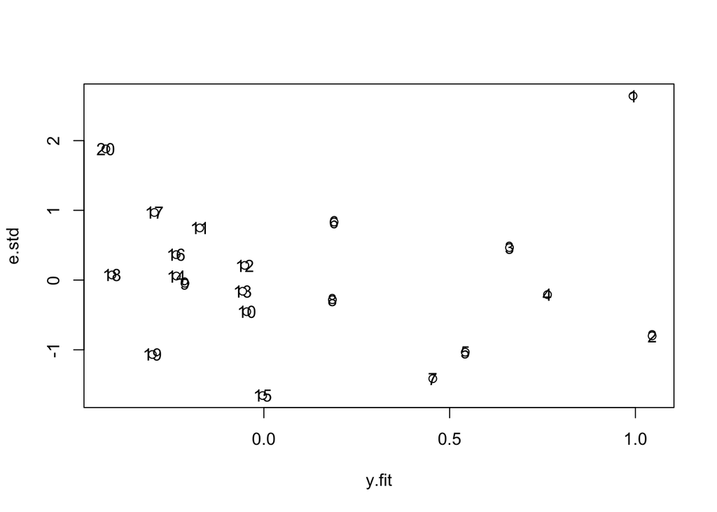

```r
plot(e.std~y.fit)
text(y.fit, e.std, type = "1:20")
```

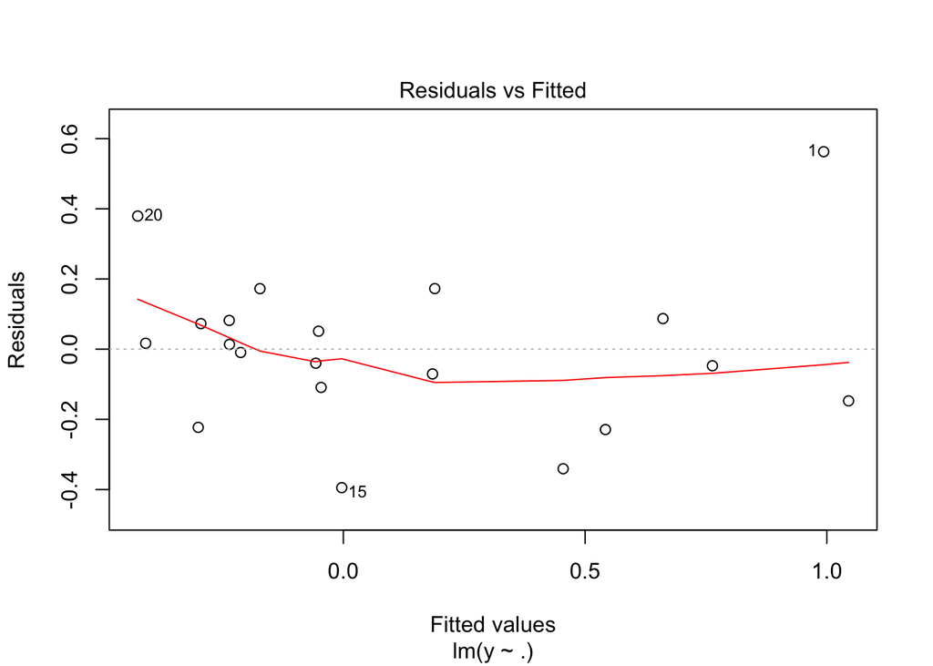

```r
plot(lm.sol, which = 1)
```

```r
e.std
```

```
##           1           2           3           4           5           6
##  2.64035438 -0.79996753  0.46539775 -0.20886024 -1.03444107  0.83205336
##           7           8           9          10          11          12
## -1.41440272 -0.28201948 -0.04531859 -0.45360372  0.74793113  0.21036654
##          13          14          15          16          17          18
## -0.16040433  0.05797991 -1.65631896  0.36447250  0.96925198  0.07349232
##          19          20
## -1.06721921  1.88081552
```

我们可以看到，第1号样本点为异常点。

```r
influence.measures(lm.sol)
```

```
## Influence measures of
##   lm(formula = y ~ ., data = data) :
##
##       dfb.1_   dfb.x1   dfb.x2   dfb.x3   dfb.x4   dfb.x5   dffit   cov.r
## 1  -0.565715 -0.13312  0.30823 -0.48846  0.12662  1.53890  2.5603  0.0377
## 2   0.096258  0.36901 -0.03403 -0.60142  0.06719 -0.13451 -0.7971  2.3803
## 3  -0.070287 -0.00632  0.10593  0.29000  0.01169 -0.21295  0.4416  2.7765
## 4   0.029645 -0.00382 -0.02428  0.04014 -0.01193 -0.06542 -0.1167  2.0440
## 5  -0.038788 -0.49975 -0.12699  0.24440  0.04577  0.19200 -0.6539  1.3528
## 6   0.014487  0.57183  0.20747 -0.37145  0.01651 -0.30716  0.6331  1.8326
## 7   0.037570  0.21276  0.28372  0.02977 -0.05820 -0.39944 -0.6259  0.7302
## 8   0.028976  0.03088  0.03525 -0.00401 -0.03986 -0.01398 -0.0840  1.6508
## 9   0.000526 -0.01558  0.00237 -0.00161 -0.00656  0.02884 -0.0330  2.4509
## 10  0.023253  0.04567  0.12464 -0.03192 -0.07276  0.03751 -0.1909  1.6955
## 11 -0.022214 -0.01685 -0.23680  0.05016  0.13441 -0.16502  0.3955  1.5744
```

[output cut: 30 more lines]

- 结论：第1号样本点为异常点，第1、2、3、9、17、20号的样本点是强影响点。由残差图和QQ图，我们接受线性假设、方差齐性假设、不相关性假设和正态性假设。